# May 13: Initial conditions for the 6D model

Emma Holmes

5/13/2020

```r
library("deSolve")
library("RColorBrewer")

# Colour palettes for graphs
greens <- brewer.pal(n = 6, name = "Greens")
colourful <- brewer.pal(n = 3, name = "Set1")
colour2 <- brewer.pal(n = 3, name = "Set2")

# Set-up
source('Code/May_2020/compare_models/pars.R')      # load parameters
source('Code/May_2020/compare_models/funcs.R')     # load functions
source('Code/May_2020/compare_models/sim_3d.R')    # load simulation file
source('Code/May_2020/compare_models/sim_6d.R')    # load simulation file

Time <- c(
  start         =     2020,
  end           =     2100,
  step          =     0.05
)
```

## Choosing initial conditions in the 6D model

The following equations link the initial conditions of the 3d model to those of the 6d model: $\omega_0 = \frac{w_0}{p_0 a_0}$, $\lambda_0 = \frac{K}{\nu N_0 a_0}$, $d_0 = \frac{\nu D_0}{p_0 K_0}$

We have $\nu=3$ and let’s assume that $p_0 = 1$ and $N_0=1$.

Then we have $\omega_0 = \frac{w_0}{a_0}$, $\lambda_0 = \frac{K}{3 a_0}$, $d_0 = \frac{3 D_0}{K_0}$.

Starting with the good intial conditions $(\lambda_0, \omega_0, d_0) = (0.9,0.9,0.3)$, we have $10D = K = 2.7 a$ and $w = 0.9 a$. So we can vary $a$ and see if the results in the 6D model are the same.

```r
a_seq <- seq(1,100,1)
K_seq <- 2.7 * a_seq
D_seq <- 0.27 * a_seq
w_seq <- 0.9 * a_seq

for (i in 1:100){
  IC_6d <- c(
  K  =  K_seq[i],
  w   =  w_seq[i],
  p   =  1,
  debt = D_seq[i],
  a = a_seq[i],
  pop = 1)

  Sim <- simulation_6d(time          = Time,
                     init_state       = IC_6d,
                     parms            = Parms,
                     method           = 'lsoda')

  cat('end result: lambda =', tail(Sim$lambda,1), 'omega =',
      tail(Sim$omega,1), 'debt share =', tail(Sim$debt_share,1),'\n')
}
```

```
## end result: lambda = 0.9697188 omega = 0.8350856 debt share = 0.1010925
## end result: lambda = 0.9687729 omega = 0.8335448 debt share = 0.1518997
## end result: lambda = 0.969003 omega = 0.8338524 debt share = 0.1414595
## end result: lambda = 0.9691323 omega = 0.8339992 debt share = 0.1365414
## end result: lambda = 0.9692083 omega = 0.8340795 debt share = 0.1338649
## end result: lambda = 0.9692576 omega = 0.8341296 debt share = 0.1321998
## end result: lambda = 0.9692921 omega = 0.8341637 debt share = 0.1310681
## end result: lambda = 0.9693175 omega = 0.8341885 debt share = 0.1302484
## end result: lambda = 0.9693369 omega = 0.8342071 debt share = 0.1296318
## end result: lambda = 0.9693523 omega = 0.8342217 debt share = 0.1291483
## end result: lambda = 0.9693648 omega = 0.8342334 debt share = 0.1287599
## end result: lambda = 0.9693751 omega = 0.8342431 debt share = 0.1284411
## end result: lambda = 0.9693837 omega = 0.8342511 debt share = 0.1281748
## end result: lambda = 0.9693911 omega = 0.834258 debt share = 0.127949
## end result: lambda = 0.9693975 omega = 0.8342638 debt share = 0.1277554
## end result: lambda = 0.969403 omega = 0.8342689 debt share = 0.1275872
## end result: lambda = 0.9694079 omega = 0.8342734 debt share = 0.1274399
## end result: lambda = 0.9694122 omega = 0.8342773 debt share = 0.1273097
## end result: lambda = 0.969416 omega = 0.8342808 debt share = 0.1271939
## end result: lambda = 0.9694195 omega = 0.834284 debt share = 0.1270903
## end result: lambda = 0.9694226 omega = 0.8342868 debt share = 0.1269969
## end result: lambda = 0.9694254 omega = 0.8342894 debt share = 0.1269124
## end result: lambda = 0.969428 omega = 0.8342917 debt share = 0.1268355
## end result: lambda = 0.9694303 omega = 0.8342938 debt share = 0.1267653
## end result: lambda = 0.9694325 omega = 0.8342958 debt share = 0.1267009
## end result: lambda = 0.9694345 omega = 0.8342976 debt share = 0.1266417
## end result: lambda = 0.9694363 omega = 0.8342992 debt share = 0.1265869
## end result: lambda = 0.969438 omega = 0.8343008 debt share = 0.1265362
## end result: lambda = 0.9694396 omega = 0.8343022 debt share = 0.1264892
## end result: lambda = 0.9694411 omega = 0.8343035 debt share = 0.1264453
## end result: lambda = 0.9694425 omega = 0.8343048 debt share = 0.1264044
## end result: lambda = 0.9694438 omega = 0.8343059 debt share = 0.1263661
## end result: lambda = 0.969445 omega = 0.834307 debt share = 0.1263302
## end result: lambda = 0.9694461 omega = 0.834308 debt share = 0.1262964
## end result: lambda = 0.9694472 omega = 0.834309 debt share = 0.1262647
## end result: lambda = 0.9694482 omega = 0.8343099 debt share = 0.1262347
## end result: lambda = 0.9694492 omega = 0.8343108 debt share = 0.1262064
## end result: lambda = 0.9694501 omega = 0.8343116 debt share = 0.1261781
## end result: lambda = 0.969451 omega = 0.8343124 debt share = 0.1261528
## end result: lambda = 0.9694518 omega = 0.8343131 debt share = 0.1261287
```

[output cut: 45 more lines]

```
## end result: lambda = 0.9694687 omega = 0.8343281 debt share = 0.1256348
## end result: lambda = 0.9694689 omega = 0.8343283 debt share = 0.1256299
## end result: lambda = 0.969469 omega = 0.8343284 debt share = 0.1256251
## end result: lambda = 0.9694692 omega = 0.8343285 debt share = 0.1256204
## end result: lambda = 0.9694693 omega = 0.8343287 debt share = 0.1256159
## end result: lambda = 0.9694695 omega = 0.8343288 debt share = 0.1256114
## end result: lambda = 0.9694697 omega = 0.834329 debt share = 0.125607
## end result: lambda = 0.9694698 omega = 0.8343291 debt share = 0.1256028
## end result: lambda = 0.9694699 omega = 0.8343292 debt share = 0.1255986
## end result: lambda = 0.9694701 omega = 0.8343293 debt share = 0.1255945
## end result: lambda = 0.9694702 omega = 0.8343295 debt share = 0.1255905
## end result: lambda = 0.9694704 omega = 0.8343296 debt share = 0.1255866
## end result: lambda = 0.9694705 omega = 0.8343297 debt share = 0.1255827
## end result: lambda = 0.9694706 omega = 0.8343298 debt share = 0.125579
## end result: lambda = 0.9694707 omega = 0.8343299 debt share = 0.1255753
```

We see that the end result varies a bit for choices of small $a$, but as $a$ increases the final results become similar. If you look at each plot, you see that with lower values of $a$ there is some oscillation, but it flattens out quickly, then all the remaining plots looks the same.

Here are some plots. The code has been changed so that the output of the 3D model with the identical initial conditions and parameters is also plotted as a dashed line.

$a=1$

```r
### Set initial conditions
IC_6d <- c(
  K  =  2.7,
  w   =  0.9,
  p   =  1,
  debt = 0.27,
  a = 1,
  pop = 1
)

omega      <- IC_6d[['w']]/ (IC_6d[['p']] * IC_6d[['a']])
lambda     <- IC_6d[['K']]/ (IC_6d[['pop']] * IC_6d[['a']] * Parms[['nu']])
debt_share <- (IC_6d[['debt']] * Parms[['nu']]) / (IC_6d[['p']] * IC_6d[['K']])

IC_3d <- c(
  lambda  =  lambda,
  omega   =  omega,
  debt    =  debt_share
)
#=================================================================================
# Set up simulation
Time <- c(
  start         =     2020,
  end           =     2100,
  step          =     0.05
)

Options <- list(
  transform_vars  = FALSE  # T / F
)

# run both
Sim_3d <- simulation_3d(time = Time,
                  init_state = IC_3d,
                  parms      = Parms,
                  options    = Options,
                  method     = 'lsoda')

Sim_6d <- simulation_6d(time          = Time,
                     init_state       = IC_6d,
                     parms            = Parms,
                     method           = 'lsoda')
```

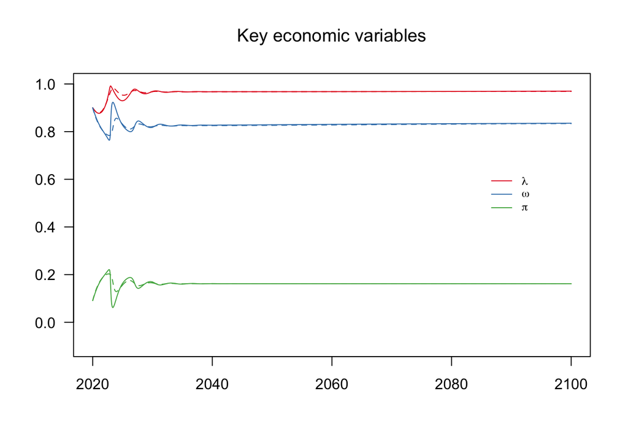

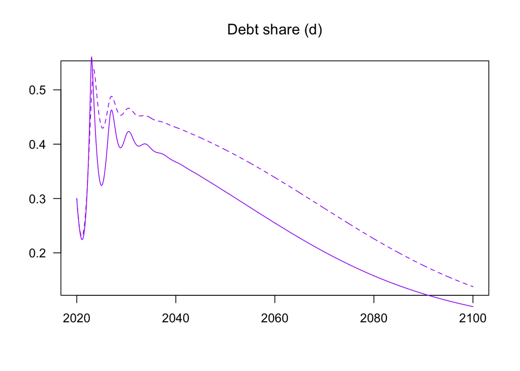

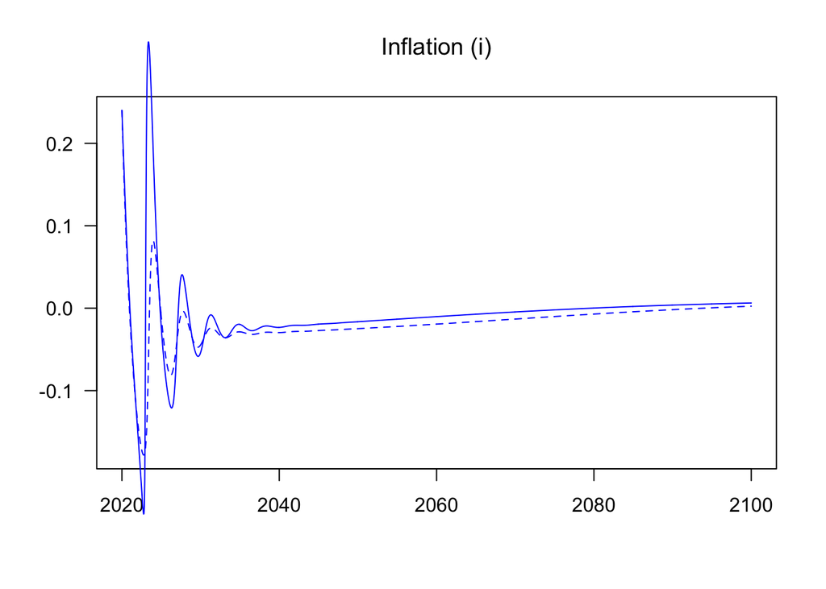

Choosing $a=2$ results in slightly less oscillation:

```r
### Set initial conditions
IC_6d <- c(
  K  =  2.7*2,
  w   =  0.9*2,
  p   =  1,
  debt = 0.27*2,
  a = 2,
  pop = 1
)

omega      <- IC_6d[['w']]/ (IC_6d[['p']] * IC_6d[['a']])
lambda     <- IC_6d[['K']]/ (IC_6d[['pop']] * IC_6d[['a']] * Parms[['nu']])
debt_share <- (IC_6d[['debt']] * Parms[['nu']]) / (IC_6d[['p']] * IC_6d[['K']])

IC_3d <- c(
  lambda  =  lambda,
  omega   =  omega,
  debt    =  debt_share
)
#=================================================================================
# Set up simulation
Time <- c(
  start         =     2020,
  end           =     2100,
  step          =     0.05
)

Options <- list(
  transform_vars  = FALSE  # T / F
)

# run both
Sim_3d <- simulation_3d(time = Time,
                  init_state = IC_3d,
                  parms      = Parms,
                  options    = Options,
                  method     = 'lsoda')

Sim_6d <- simulation_6d(time          = Time,
                     init_state       = IC_6d,
                     parms            = Parms,
                     method           = 'lsoda')
```

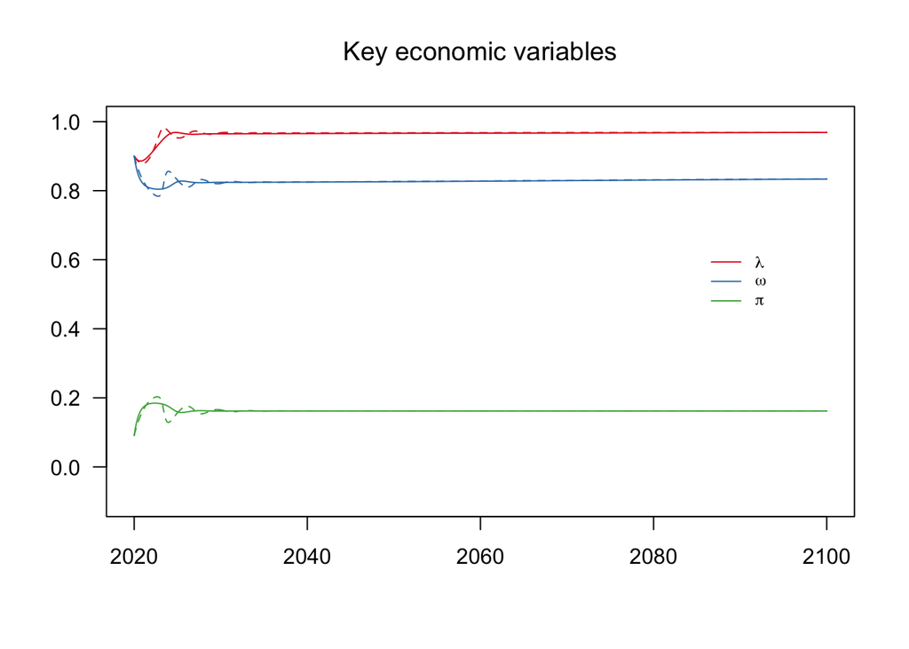

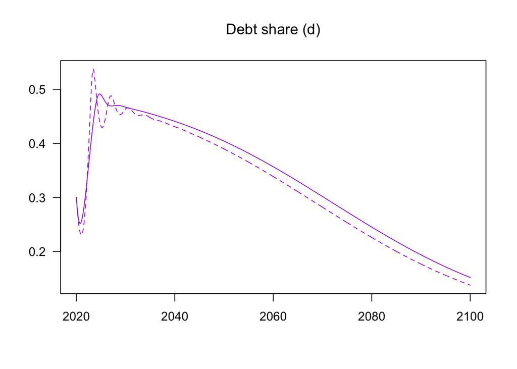

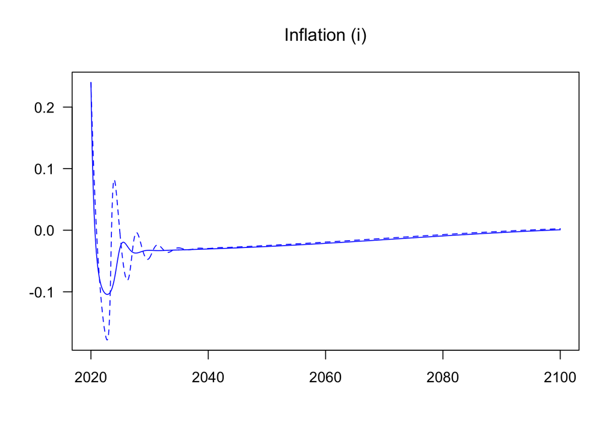

Choosing $a=100$ results in very little oscillation:

```r
### Set initial conditions
IC_6d <- c(
  K  =  2.7*100,
  w   =  0.9*100,
  p   =  1,
  debt = 0.27*100,
  a = 100,
  pop = 1
)

omega      <- IC_6d[['w']]/ (IC_6d[['p']] * IC_6d[['a']])
lambda     <- IC_6d[['K']]/ (IC_6d[['pop']] * IC_6d[['a']] * Parms[['nu']])
debt_share <- (IC_6d[['debt']] * Parms[['nu']]) / (IC_6d[['p']] * IC_6d[['K']])

IC_3d <- c(
  lambda  =  lambda,
  omega   =  omega,
  debt    =  debt_share
)
#=================================================================================
# Set up simulation
Time <- c(
  start         =     2020,
  end           =     2100,
  step          =     0.05
)

Options <- list(
  transform_vars  = FALSE  # T / F
)

# run both
Sim_3d <- simulation_3d(time = Time,
                  init_state = IC_3d,
                  parms      = Parms,
                  options    = Options,
                  method     = 'lsoda')

Sim_6d <- simulation_6d(time          = Time,
                     init_state       = IC_6d,
                     parms            = Parms,
                     method           = 'lsoda')
```

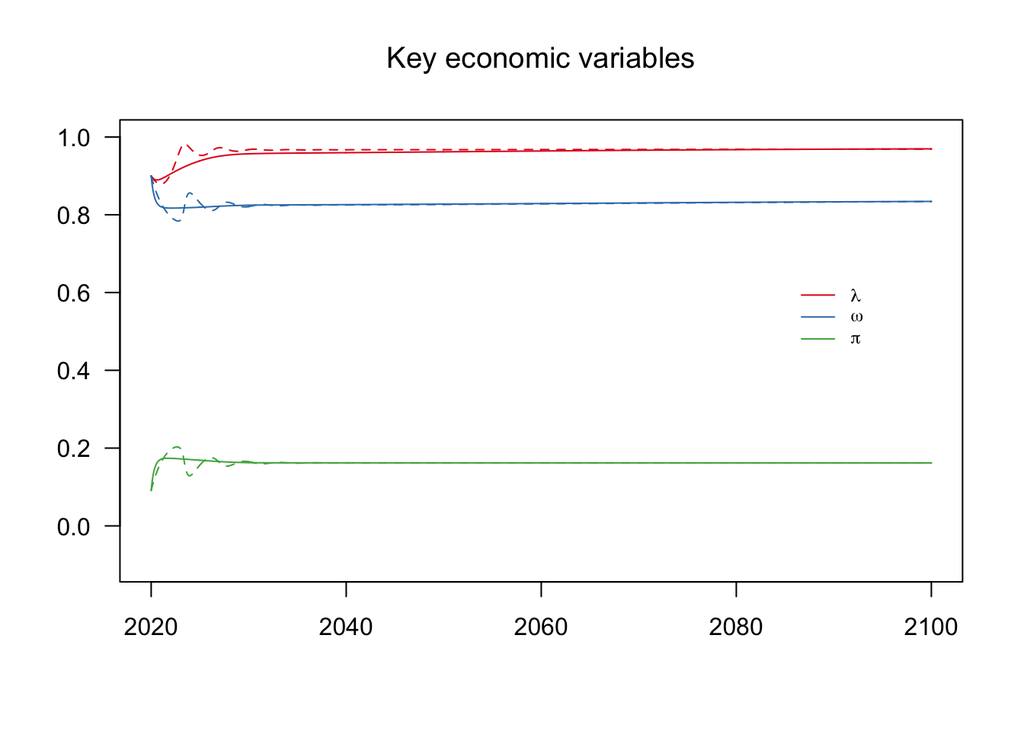

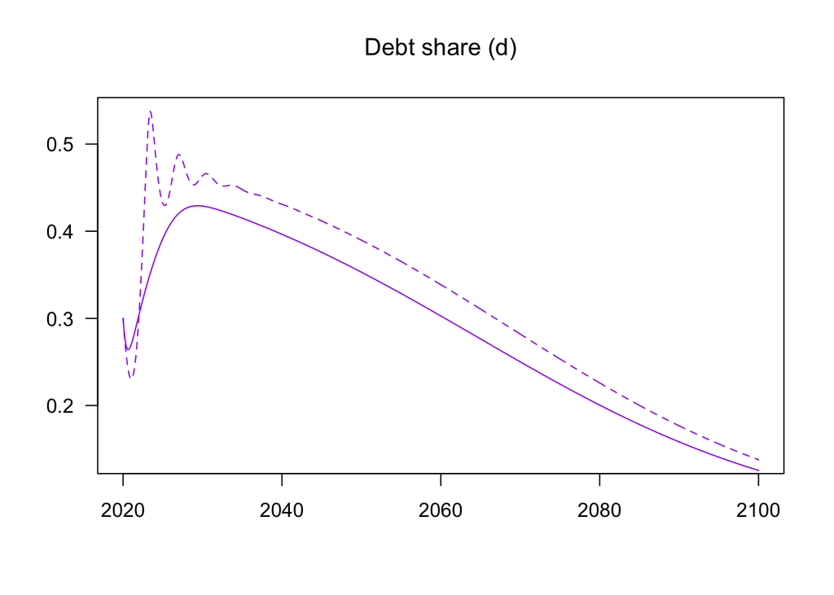

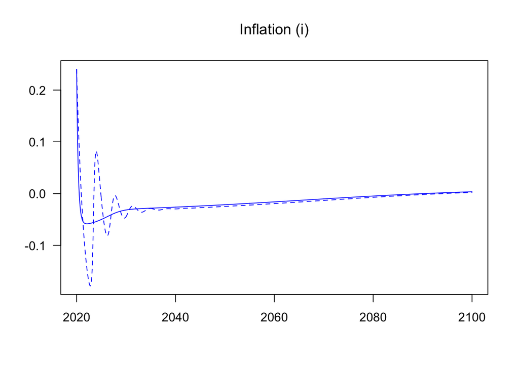

Given these results, I will choose $a_0=1$, which means for the intial conditions for the “good”" base case are:
$$K_0 = 2.7\\
w_0 = 0.9\\
p_0 = 1 \\
D_0 = 0.27 \\
a_0 = 1 \\
N_0 = 1 \\$$